# reporte_oscuridad

## Analisis de sociedades con oscuridad completa

```python
import pandas as pd
import seaborn as sns
import numpy as np

import matplotlib.pyplot as plt
sns.set(rc={'figure.figsize':(20,10)})
```

Usaremos el output de la segunda version de ejecucion:

*artefactos/Ejecucionv2/Sociedades_oscuridad_completa.csv*: archivo con rut de la sociedad completada, su valor de ocuridad y el numero de iteraciones para lograr la completitud.

*artefactos/Ejecucionv2/Sociedades_oscuridad_actualizada.csv*: archivo con los datos de composicion y oscuridad de todas las sociedades con oscuridad por socio, incluidos los datos faltantes.

```python
complete = pd.read_csv('Sociedades_oscuridad_completa.csv', delimiter=',')
society_all= pd.read_csv('Sociedades_oscuridad_actualizada.csv', delimiter=',')
```

```python
len(society_all['RUT_SOCIEDAD'].unique()), len(complete)
```

```
(1391761, 1349646)
```

```python
len(complete) /(len(society_all['RUT_SOCIEDAD'].unique()))*100
```

```
96.9739775722987
```

```python
complete.describe()
```

|  | Value | iterations |
| --- | --- | --- |
| count | 1.349646e+06 | 1.349646e+06 |
| mean | 2.459081e-01 | 7.249308e-02 |
| std | 5.944524e-02 | 3.750133e-01 |
| min | 0.000000e+00 | 0.000000e+00 |
| 25% | 2.505881e-01 | 0.000000e+00 |
| 50% | 2.505881e-01 | 0.000000e+00 |
| 75% | 2.505881e-01 | 0.000000e+00 |
| max | 1.000000e+00 | 5.000000e+00 |

Vemos que los cuartiles son muy similares, por lo cual analizamos co un histograma par aver la distribucion.

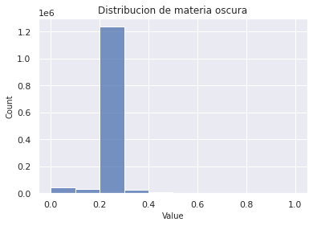

```python
x = complete['Value']
sns.histplot(x = x, bins=10).set_title('Distribucion de materia oscura')
sns.set(font_scale=1)
```

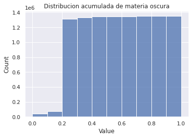

```python
x = complete['Value']
sns.histplot(x = x, bins=10, cumulative=True).set_title('Distribucion acumulada de materia oscura')
sns.set(font_scale=1)
```

Comparado al total de datos, las personas juridicas con mas oscuridad que 0.4, parece ser marginal. Ahora bien, en cuanto a las iteraciones y la completitud, vemos que:

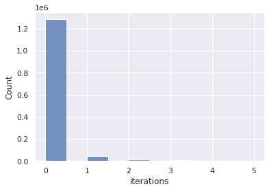

```python
x = complete['iterations']
sns.histplot(x = x,  bins=10)
sns.set(font_scale=1)
```

Es decir, la mayoria de las sociedades son completadas en la primera iteracion. Grafiquemos iteracions vs oscuridad.

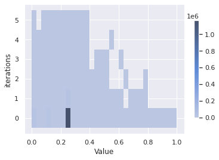

```python
sns.histplot(
    complete, x="Value", y="iterations",
    bins=30, discrete=(False, True),
    cbar=True, cbar_kws=dict(shrink=.75),
)
```

Vemos que la mayoria de los registros es completado en 1 iteracion y tienen oscuridad cercana a 0.2 Ahora analicemos los registros con valores mayores o iguales a una oscuridad de 0.75.

```python
sup=complete[complete['Value']>=0.75]
sup.describe()
```

|  | Value | iterations |
| --- | --- | --- |
| count | 2066.000000 | 2066.000000 |
| mean | 0.795835 | 0.003872 |
| std | 0.032634 | 0.069481 |
| min | 0.750196 | 0.000000 |
| 25% | 0.791177 | 0.000000 |
| 50% | 0.791177 | 0.000000 |
| 75% | 0.791177 | 0.000000 |
| max | 1.000000 | 2.000000 |

Observemos que son solo un poco mas de 2000 sociedades con estas caracteristicas. Recordemos que las iteraciones corresponden a niveles de relacion, a mayor profundida de la relacion es necesario mas iteraciones para completar las sociedades. Veamos la distribucion de materia oscura en esta seleccion.

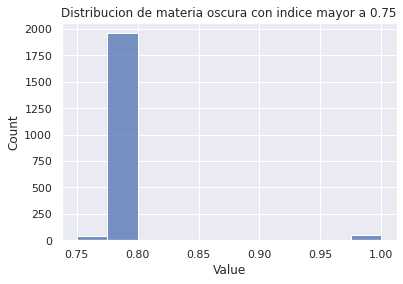

```python
x = sup['Value']
sns.histplot(x = x,  bins=10, cumulative=False).set_title('Distribucion de materia oscura con indice mayor a 0.75')
sns.set(font_scale=1)
```

```python
sup.describe()
```

|  | Value | iterations |
| --- | --- | --- |
| count | 2066.000000 | 2066.000000 |
| mean | 0.795835 | 0.003872 |
| std | 0.032634 | 0.069481 |
| min | 0.750196 | 0.000000 |
| 25% | 0.791177 | 0.000000 |
| 50% | 0.791177 | 0.000000 |
| 75% | 0.791177 | 0.000000 |
| max | 1.000000 | 2.000000 |

En este caso, tenemos que el maximo de profundidad es 2 y casi todos los valores de oscuridad rondan a 0.79

Finalmente, tambien tenemos personas juridicas con valor de oscuridad igual a 1.

```python
max=complete[complete['Value']==1]
max.describe()
```

|  | Value | iterations |
| --- | --- | --- |
| count | 46.0 | 46.0 |
| mean | 1.0 | 0.0 |
| std | 0.0 | 0.0 |
| min | 1.0 | 0.0 |
| 25% | 1.0 | 0.0 |
| 50% | 1.0 | 0.0 |
| 75% | 1.0 | 0.0 |
| max | 1.0 | 0.0 |

Tenemos 46 personas juridicas con oscuridad igual a 1, completadas todas en la primera iteracion, es decir todos sus socios son personas naturales.

```python
!pip install nbconvert
```

```python
!jupyter nbconvert --to html report1.ipynb
```

[output not shown]

[output cut: 125 more lines]

[output not shown]